# EC1 – Applied Data Science

### 7.1 Price vs Rooms (RM → MEDV)

- **Goal**: See how price (MEDV) changes with average number of rooms (RM).
- **Hypothesis**: More rooms → higher price.

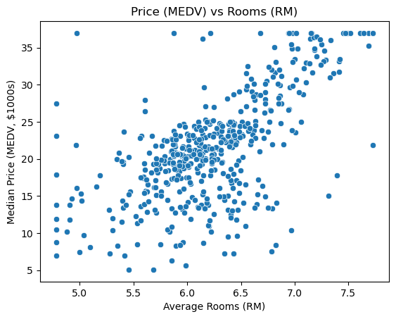

```python
sns.scatterplot(x=df["RM"], y=df["MEDV"])
plt.title("Price (MEDV) vs Rooms (RM)")
plt.xlabel("Average Rooms (RM)")
plt.ylabel("Median Price (MEDV, $1000s)")
plt.show()
```

**Interpretation:** Clear upward relationship—more rooms associates with higher price.

**Business meaning:** Larger homes can be positioned as premium; RM is a key factor in valuation and listing emphasis.

**Business KPI Link:** RM (average rooms) is directly tied to property valuation; more rooms typically support higher listing prices.

### 7.2 Price vs Crime Rate (CRIM → MEDV)

**Goal:** Check impact of neighborhood safety on price. Hypothesis: Higher crime rate reduces price.

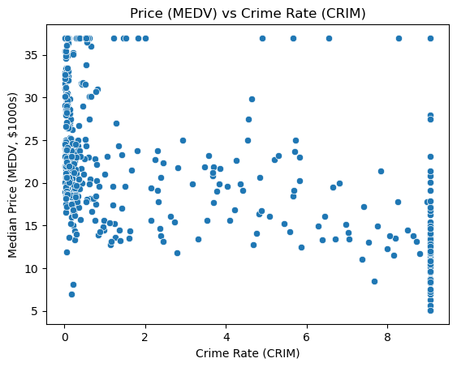

```python
sns.scatterplot(x=df["CRIM"], y=df["MEDV"])
plt.title("Price (MEDV) vs Crime Rate (CRIM)")
plt.xlabel("Crime Rate (CRIM)")
plt.ylabel("Median Price (MEDV, $1000s)")
plt.show()
```

**Interpretation:** Downward pattern—higher CRIM tends to align with lower MEDV.

**Business meaning:** Safety initiatives and crime reduction can support property values; useful for planning and pricing.

**Business KPI Link:** CRIM acts as a neighborhood risk KPI; lower crime areas can be marketed as premium or family-friendly zones.

### 7.3 Price vs Pupil–Teacher Ratio (PTRATIO → MEDV)

**Goal:** See if better student attention (lower PTRATIO) relates to price.

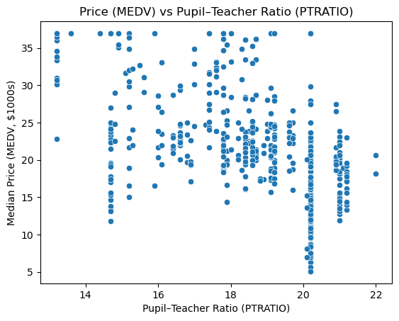

```python
sns.scatterplot(x=df["PTRATIO"], y=df["MEDV"])
plt.title("Price (MEDV) vs Pupil–Teacher Ratio (PTRATIO)")
plt.xlabel("Pupil–Teacher Ratio (PTRATIO)")
plt.ylabel("Median Price (MEDV, $1000s)")
plt.show()
```

**Interpretation:** Lower PTRATIO often aligns with higher prices.

**Business meaning:** School quality matters; marketers can target family buyers with school metrics.

**Business KPI Link:** PTRATIO is a proxy for school quality; real estate firms use this metric when positioning homes to families.

### 7.4 Distribution of House Prices

**Goal:** Understand typical price range and any upper cap.

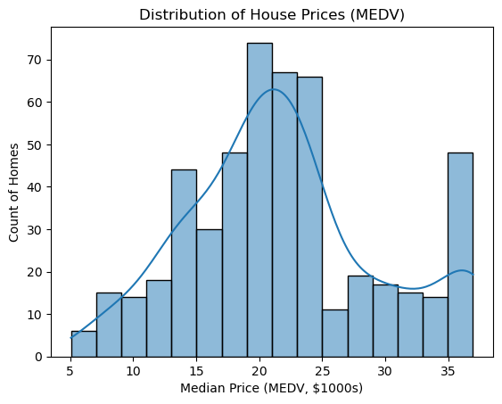

```python
sns.histplot(df["MEDV"], kde=True)
plt.title("Distribution of House Prices (MEDV)")
plt.xlabel("Median Price (MEDV, $1000s)")
plt.ylabel("Count of Homes")
plt.show()
```

**Business meaning:** Be cautious with the highest price band—recording cap may hide true extremes.

### 7.5 Correlation Heatmap

**Goal:** Quick overview of relationships among variables.

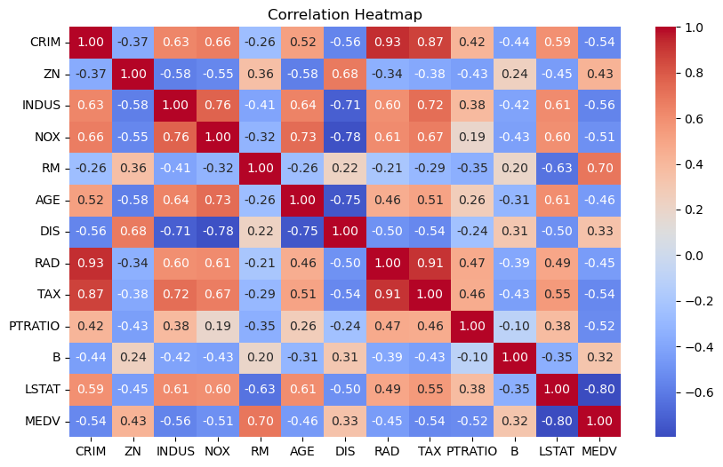

```python
plt.figure(figsize=(10,6))
sns.heatmap(df.corr(numeric_only=True), annot=True, cmap="coolwarm", fmt=".2f")
plt.title("Correlation Heatmap")
plt.show()
```

**Interpretation:** MEDV shows positive link with RM and negative with LSTAT, CRIM, PTRATIO.

**Business meaning:** Emphasize home features (rooms) and neighborhood factors (safety, socioeconomics, school ratio).

```python
from IPython.display import Markdown, display

display(Markdown("""
### Key Insights Summary

| Feature | Relationship with Price (MEDV) | Business Interpretation |
|--------|---------------------------------|--------------------------|
| RM     | Strong Positive                 | Larger homes command higher prices |
| CRIM   | Negative                        | Safer areas have higher property values |
| PTRATIO| Negative                        | Better school access increases demand |
| LSTAT  | Strong Negative                 | Socioeconomic conditions impact pricing |
"""))
```

Key Insights Summary

| Feature | Relationship with Price (MEDV) | Business Interpretation |
| --- | --- | --- |
| RM | Strong Positive | Larger homes command higher prices |
| CRIM | Negative | Safer areas have higher property values |
| PTRATIO | Negative | Better school access increases demand |
| LSTAT | Strong Negative | Socioeconomic conditions impact pricing |

### 7.6 Save Cleaned Dataset

We export the cleaned dataset to a CSV file for submission and for any future analysis. We set index=False so that the row numbers (0, 1, 2, …) are not stored as an extra column.

```python
df.to_csv("cleaned_boston.csv", index=False)
```

**Result:** File cleaned_boston.csv is created in the current working folder (visible in the left 14 panel). If required, we can save to a subfolder, e.g., ‘outputs/cleaned_boston.csv

### Phase 2: Business Narrative Summary

The exploratory analysis of the Boston Housing dataset highlights four major factors that strongly influence residential property values:

1. **Structural Features (RM):** Homes with more rooms consistently show higher prices. This is a key selling point for developers and sellers, indicating that structural improvements and larger layouts add measurable economic value.
2. **Neighborhood Safety (CRIM):** Higher crime rates correspond to lower property prices. For urban planners and policymakers, this insight reinforces the long-term benefit of safety initiatives in improving housing market performance.
3. **Education Quality (PTRATIO):** Lower pupil–teacher ratios are associated with higher home values. This KPI is important for families and directly affects how real estate companies position properties located near well-rated schools.
4. **Socioeconomic Indicators (LSTAT):** Neighborhoods with lower percentages of lowerincome residents tend to have higher property values. This reinforces the role of socioeconomic development in shaping housing demand.

### Implications for Stakeholders

- **Real Estate Developers:** Highlight room count, school quality, and safety metrics in marketing campaigns.
- **Policy Makers:** Investments in education, safety, and community upliftment can improve long-term property values.
- **Buyers & Investors:** These indicators provide a research-backed basis for understanding neighborhood value differences.

The cleaned dataset and EDA outputs now form a strong foundation for Phase 3, where these insights will be consolidated into a comprehensive business report with ethical onsiderations and strategic recommendations.

### Phase‑2 Conclusion (Bridge to Phase‑3)

**Next (Phase‑3)**: Compile a short executive report and a concise slide deck with:

1. key visuals + captions,
2. stakeholder‑focused recommendations,
3. ethical considerations and limitations (historic data, MEDV top‑coding).

## Phase 2 report Ends Here

# Phase 3: End-Term Phase

## Focus: Final analysis, reporting, and ethical considerations (Step 8–9)

- Finalize Jupyter Notebook with logical structure. AS much as possible, your notebook should be having sufficient markdown cells with clear explanation.
- Refine 4–6 key visualizations with business interpretations. Ensure the KPIs reflect your business objectives.

## Ethics & Limitations (Notebook Summary)

- **Sensitive attribute caution:** LSTAT reflects socio-economic vulnerability—use responsibly to avoid stigmatization.
- **Capped prices:** MEDV top-coding (~50) limits luxury-level interpretation.
- **Outlier capping:** IQR clipping preserves all 506 rows but compresses extremes; visuals become clearer while true max/min may be understated.
- **Responsible use:** Apply insights to community uplift (safety, schooling), not exclusionary practices.

# Thank You :)